# 3 Assignment 3

### 3.2. Reading and Exploring the data

Reading the data created in Data Wrangling part from a local folder:

```r
# access all the libraries needed in the assignment 3:
library(dplyr)
library(tidyverse)
library(GGally)
library(ggplot2)

# Read the .csv file created in the Data wrangling:
alc <- read_csv(file="C:\\Users\\kuud\\Work Folders\\IODS\\IODS-project\\data\\alc.csv")
```

The data attributes include Portuguese secondary education student grades (first, second and final grade; G1-G3), socio-demographic and education related features, and it was collected by using school reports and questionnaires. This data set **alc** combines two data in two distinct subjects; Mathematics (mat) and Portuguese language (por). More information about the open data sets used in this Assignment can be found [here](http://www.archive.ics.uci.edu/dataset/320/student+performance). In addition to the original variables this data has two additional alcohol-related variables: **alc_use** is the average of **Dalc** (Workday alcohol consumption) and **Walc** (weekend alcohol consumption) and **high_use** is TRUE if **alc_use** is higher than 2 and FALSE otherwise. The list of variables is shown below.

```r
# Column names of the data set
colnames(alc)
```

```
##  [1] "school"     "sex"        "age"        "address"    "famsize"
##  [6] "Pstatus"    "Medu"       "Fedu"       "Mjob"       "Fjob"
## [11] "reason"     "guardian"   "traveltime" "studytime"  "schoolsup"
## [16] "famsup"     "activities" "nursery"    "higher"     "internet"
## [21] "romantic"   "famrel"     "freetime"   "goout"      "Dalc"
## [26] "Walc"       "health"     "failures"   "paid"       "absences"
## [31] "G1"         "G2"         "G3"         "alc_use"    "high_use"
```

### 3.3. Choosing the variables

> Assignment: *Choose 4 interesting variables in the data and for each of them, present your personal hypothesis about their relationships with alcohol consumption.*

There are many interesting variables to choose from, but here I wanted to examine the possible effect of the family socioeconomic status (SES) and family relationships on students alcohol consumption, so I chose the parents education (**Medu** = mothers education, **Fedu** = fathers education), home address type (**address** = urban or rural) and the quality of family relationships (**famrel**). Income would have been a nice addition, but that information was not collected. My hypothesis is that higher education of the parents, living in urban area and having a good family relations might predict using less alcohol. I’m interested to see if mothers and fathers education have differ on the effect they have on their childrens alcohol consumption. Although alcohol use is a bit difficult to predict with different socioeconomic variables, since for example drinking wine with meals is usually more typical in middle-high and high-income families, when drinking beer and other similar beverages might be more common in low-income families, at least in some countries. Let’s see what this data has to say about the relationship of family SES and relationships with students alcohol consumption.

##### **Mothers and fathers education (Medu & Fedu):**

Let’s explore the parents education:

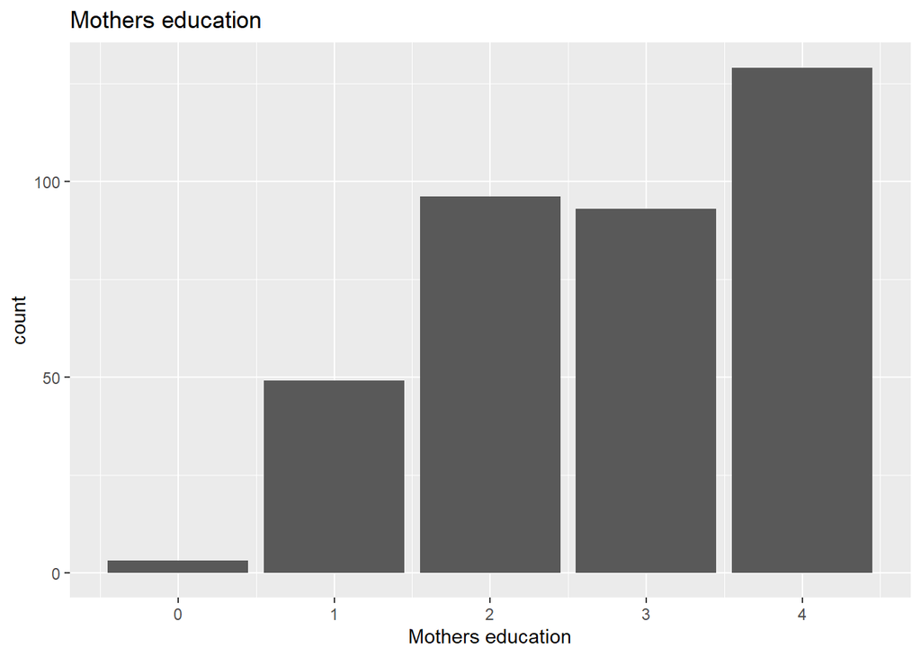

```r
# Mothers education
me <- ggplot(data = alc, aes(x = Medu)) +
  geom_bar() +
  ggtitle("Mothers education") +
  xlab("Mothers education")
me
```

```r
# frequency table
table(alc$Medu)
```

```
##
##   0   1   2   3   4
##   3  49  96  93 129
```

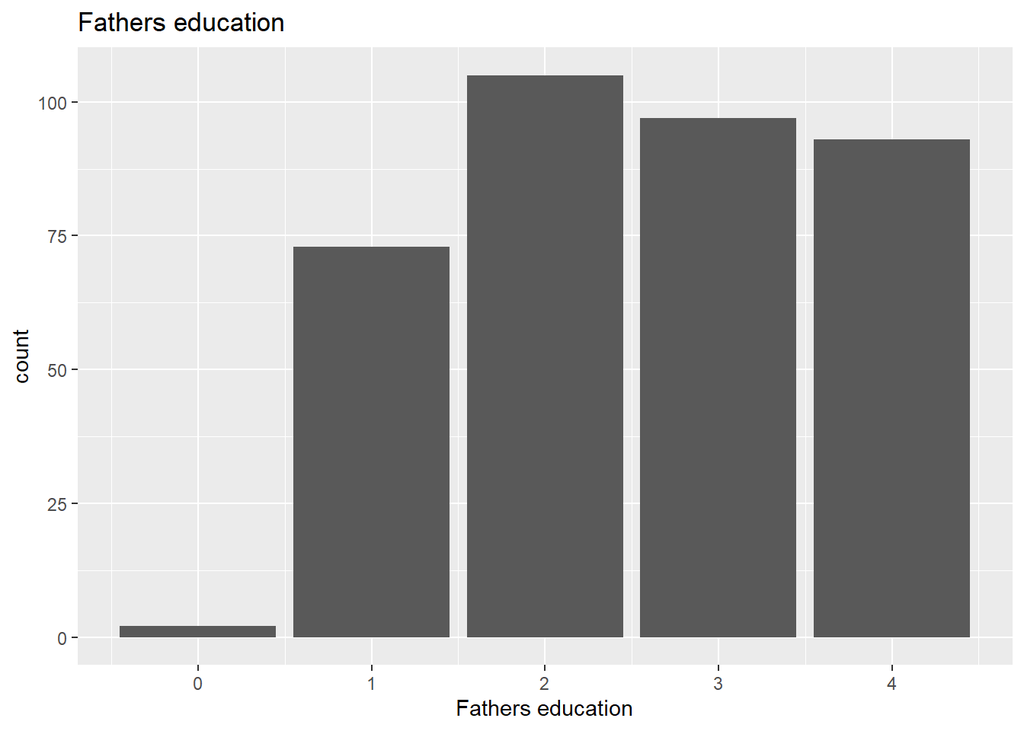

```r
# Fathers education
fe <- ggplot(data = alc, aes(x = Fedu)) +
  geom_bar() +
  ggtitle("Fathers education") +
  xlab("Fathers education")
fe
```

```r
# frequency table
table(alc$Fedu)
```

```
##
##   0   1   2   3   4
##   2  73 105  97  93
```

It seems that there are only 3 mothers and 2 fathers with no education (0 = no education). I decided to combine the “no education” to “primary education” (see below), so that the new variables are **Medu_cat** and **Fedu_cat** with the following data: 1 = primary education (4th grade) or less, 2 = 5th to 9th grade, 3 = secondary education and 4 = higher education.

```r
# Recoding the no education category 0 into 1 for mothers education
alc$Medu_cat <- recode(alc$Medu, '0' = 1)
# checking the frequency table of the new variable compared to the origial
table(alc$Medu)
```

```
##
##   0   1   2   3   4
##   3  49  96  93 129
```

```r
table(alc$Medu_cat)
```

```
##
##   1   2   3   4
##  52  96  93 129
```

```r
# Recoding the no education category 0 into 1 for fathers education
alc$Fedu_cat <- recode(alc$Fedu, '0' = 1)
# checking the frequency tables of the new variable compared to the origial
table(alc$Fedu)
```

```
##
##   0   1   2   3   4
##   2  73 105  97  93
```

```r
table(alc$Fedu_cat)
```

```
##
##   1   2   3   4
##  75 105  97  93
```

##### **Address:**

It seems that majority of the students lives in urban area.

```r
# frequency table
table(alc$address)
```

```
##
##   R   U
##  81 289
```

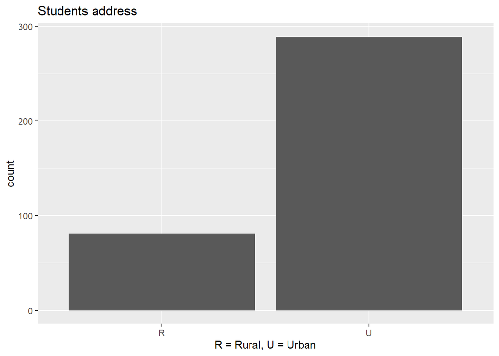

```r
# Plot
ad <- ggplot(data = alc, aes(x = address)) +
  geom_bar() +
  ggtitle("Students address") +
  xlab("R = Rural, U = Urban")
ad
```

#### **Guality of family relationships:**

Majority of the students (about 75 %) have very good family relations (4 or 5 on a 1-5 scale), but also worse relations exists.

```r
# frequency table
table(alc$famrel)
```

```
##
##   1   2   3   4   5
##   8  18  64 180 100
```

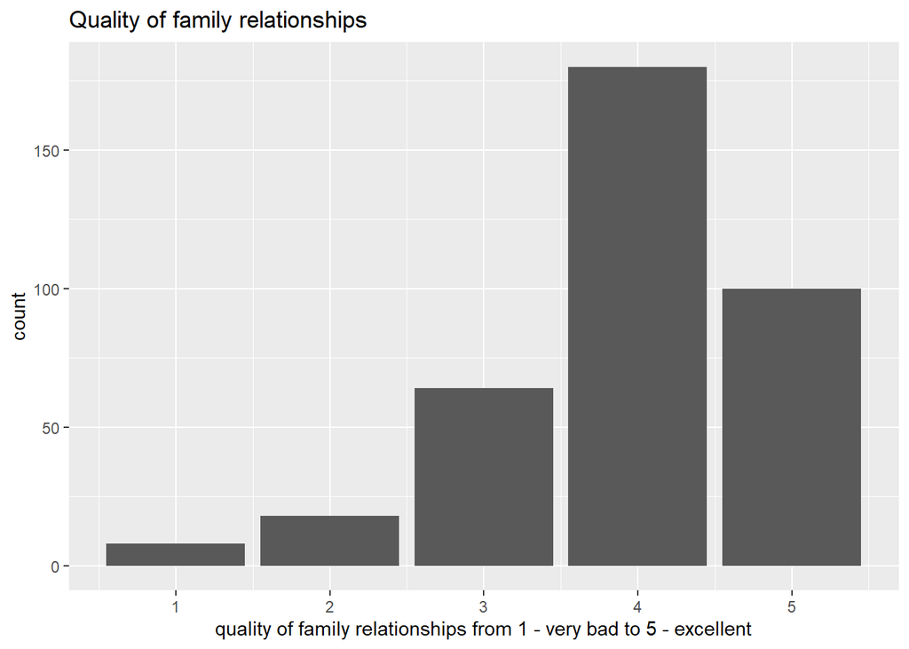

```r
# Plot
fam <- ggplot(data = alc, aes(x = famrel)) +
  geom_bar() +
  ggtitle("Quality of family relationships") +
  xlab("quality of family relationships from 1 - very bad to 5 - excellent")
fam
```

#### **Alcohol consumption:**

Let’s explore also the alcohol use (**alc_use**) and high consumption of alcohol (**high_use**) in this data:.

```r
# frequency table
table(alc$alc_use)
```

```
##
##   1 1.5   2 2.5   3 3.5   4 4.5   5
## 140  63  56  41  32  17   9   3   9
```

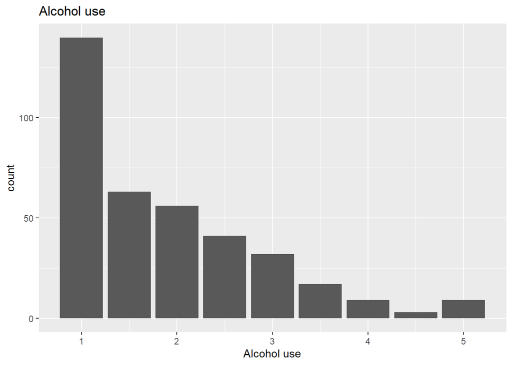

```r
# Plot
au <- ggplot(data = alc, aes(x = alc_use)) +
  geom_bar() +
  ggtitle("Alcohol use") +
  xlab("Alcohol use")
au
```

```r
# frequency table
table(alc$alc_use)
```

```
##
##   1 1.5   2 2.5   3 3.5   4 4.5   5
## 140  63  56  41  32  17   9   3   9
```

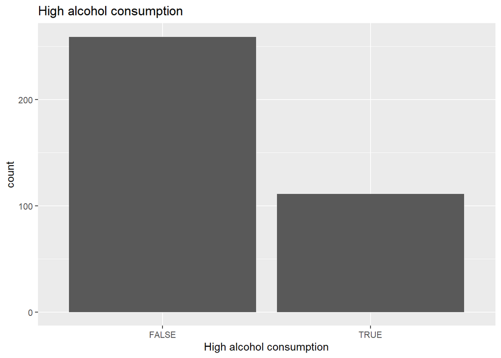

```r
# Plot
hu <- ggplot(data = alc, aes(x = high_use)) +
  geom_bar() +
  ggtitle("High alcohol consumption") +
  xlab("High alcohol consumption")
hu
```

### 3.4. Relationship between the chosen variables and alcohol consumption

Next, I’ll explore the relationships of **Medu_cat**, **Fedu_cat** (parents education categorised into 4), **address** (urban and rural) and **famrel** (scale from 1 - bad to 5 - excellent) to high alcohol consumption: **high_use**.

```r
# percentage frequency table; high_use and mothers education
table1 <- table(alc$Medu_cat, alc$high_use)
round(prop.table(table1), 3)
```

```
##
##     FALSE  TRUE
##   1 0.086 0.054
##   2 0.211 0.049
##   3 0.154 0.097
##   4 0.249 0.100
```

```r
# percentage frequency table; high_use and fathers education
table2 <- table(alc$Fedu_cat, alc$high_use)
round(prop.table(table2), 3)
```

```
##
##     FALSE  TRUE
##   1 0.138 0.065
##   2 0.203 0.081
##   3 0.189 0.073
##   4 0.170 0.081
```

```r
# percentage frequency table; high_use and address
table3 <- table(alc$address, alc$high_use)
round(prop.table(table3), 3)
```

```
##
##     FALSE  TRUE
##   R 0.135 0.084
##   U 0.565 0.216
```

```r
# percentage frequency table; high_use and famrel
table4 <- table(alc$famrel, alc$high_use)
round(prop.table(table4), 3)
```

```
##
##     FALSE  TRUE
##   1 0.016 0.005
##   2 0.024 0.024
##   3 0.105 0.068
##   4 0.346 0.141
##   5 0.208 0.062
```

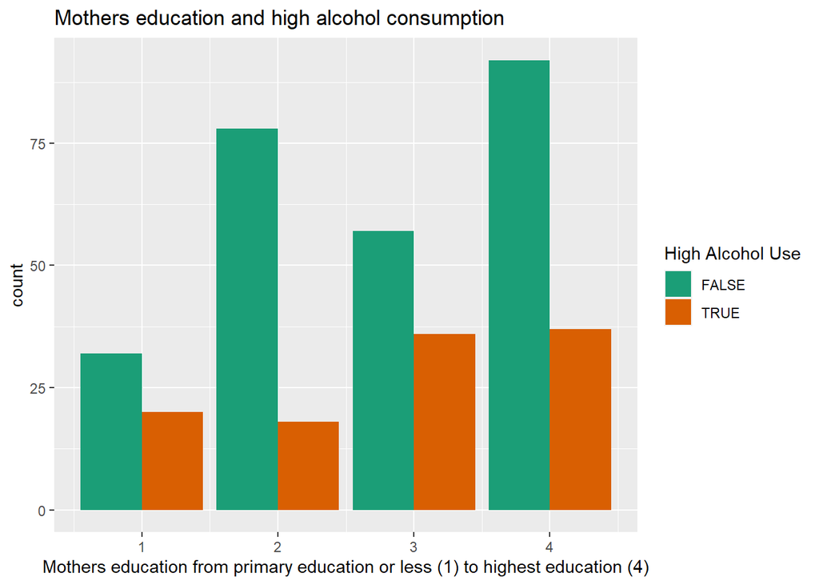

```r
# Bar-plots:
# high_use by mothers education

mehu <- ggplot(data = alc, aes(x = Medu_cat, fill = high_use)) +
  geom_bar(position=position_dodge()) +
  ggtitle("Mothers education and high alcohol consumption") +
  xlab("Mothers education from primary education or less (1) to highest education (4)") +
  scale_fill_brewer(palette="Dark2") +
  labs(fill="High Alcohol Use")
mehu
```

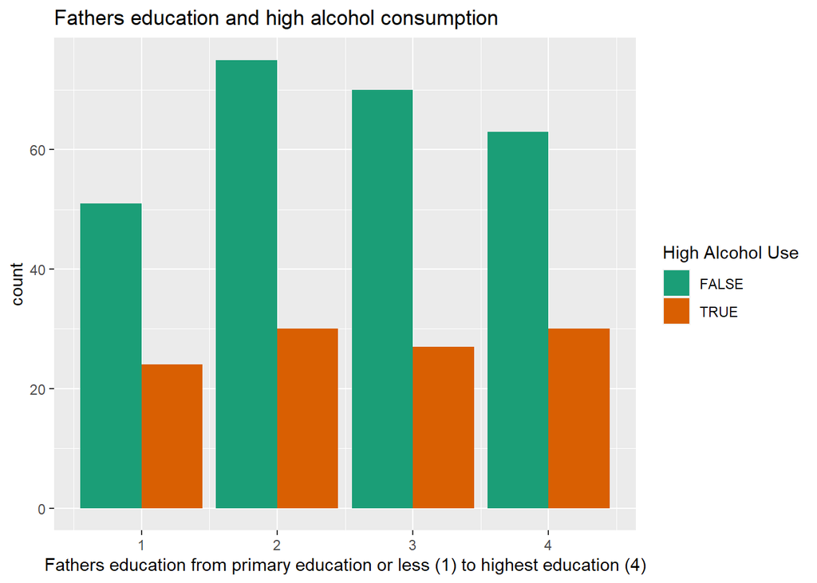

```r
# high_use by fathers education
fehu <- ggplot(data = alc, aes(x = Fedu_cat, fill = high_use)) +
  geom_bar(position=position_dodge()) +
  ggtitle("Fathers education and high alcohol consumption") +
  xlab("Fathers education from primary education or less (1) to highest education (4)") +
  scale_fill_brewer(palette="Dark2") +
  labs(fill="High Alcohol Use")
fehu
```

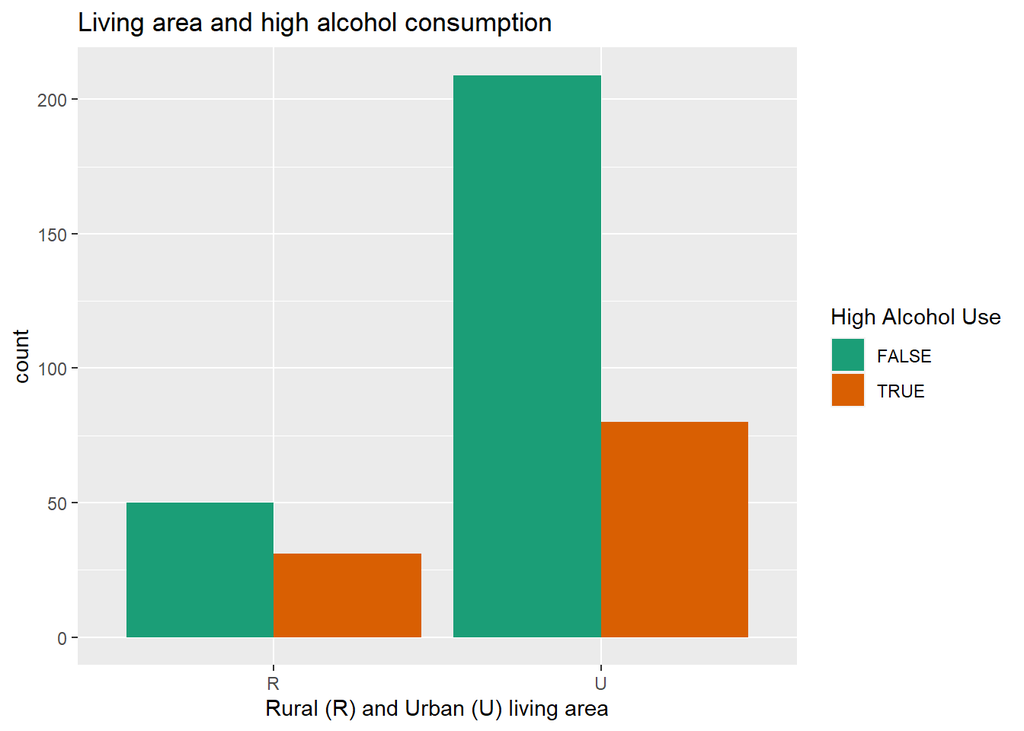

```r
# high_use by address
adhu <- ggplot(data = alc, aes(x = address, fill = high_use)) +
  geom_bar(position=position_dodge()) +
  ggtitle("Living area and high alcohol consumption") +
  xlab("Rural (R) and Urban (U) living area") +
  scale_fill_brewer(palette="Dark2") +
  labs(fill="High Alcohol Use")
adhu
```

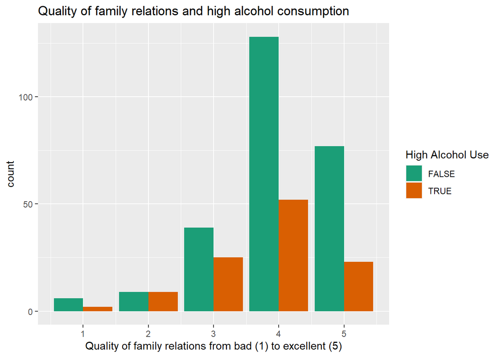

```r
# high_use by quality of family relations
fahu <- ggplot(data = alc, aes(x = famrel, fill = high_use)) +
  geom_bar(position=position_dodge()) +
  ggtitle("Quality of family relations and high alcohol consumption") +
  xlab("Quality of family relations from bad (1) to excellent (5)") +
  scale_fill_brewer(palette="Dark2") +
  labs(fill="High Alcohol Use")
fahu
```

```r
# Summary statistics by group
alc %>% group_by(Medu_cat, high_use) %>% summarise(count = n())
```

```
## # A tibble: 8 × 3
## # Groups:   Medu_cat [4]
##   Medu_cat high_use count
##      <dbl> <lgl>    <int>
## 1        1 FALSE       32
## 2        1 TRUE        20
## 3        2 FALSE       78
## 4        2 TRUE        18
## 5        3 FALSE       57
## 6        3 TRUE        36
## 7        4 FALSE       92
## 8        4 TRUE        37
```

```r
alc %>% group_by(Fedu_cat, high_use) %>% summarise(count = n())
```

```
## # A tibble: 8 × 3
## # Groups:   Fedu_cat [4]
##   Fedu_cat high_use count
##      <dbl> <lgl>    <int>
## 1        1 FALSE       51
## 2        1 TRUE        24
## 3        2 FALSE       75
## 4        2 TRUE        30
## 5        3 FALSE       70
## 6        3 TRUE        27
## 7        4 FALSE       63
## 8        4 TRUE        30
```

```r
alc %>% group_by(address, high_use) %>% summarise(count = n())
```

```
## # A tibble: 4 × 3
## # Groups:   address [2]
##   address high_use count
##   <chr>   <lgl>    <int>
## 1 R       FALSE       50
## 2 R       TRUE        31
## 3 U       FALSE      209
## 4 U       TRUE        80
```

```r
alc %>% group_by(famrel, high_use) %>% summarise(count = n())
```

```
## # A tibble: 10 × 3
## # Groups:   famrel [5]
##    famrel high_use count
##     <dbl> <lgl>    <int>
##  1      1 FALSE        6
##  2      1 TRUE         2
##  3      2 FALSE        9
##  4      2 TRUE         9
##  5      3 FALSE       39
##  6      3 TRUE        25
##  7      4 FALSE      128
##  8      4 TRUE        52
##  9      5 FALSE       77
## 10      5 TRUE        23
```

### 3.5. Logistic regression

Let’s make a logistic regression with the values we have. The goal is to see whether variables predict binary value of high consumption of alcohol.

```r
# logistic regression model and summary of the model
m <- glm(high_use ~ Medu_cat + Fedu_cat + address + famrel, data = alc, family = "binomial")
# summary of the model
summary(m)
```

```
##
## Call:
## glm(formula = high_use ~ Medu_cat + Fedu_cat + address + famrel,
##     family = "binomial", data = alc)
##
## Deviance Residuals:
##     Min       1Q   Median       3Q      Max
## -1.2190  -0.8369  -0.7768   1.3875   1.7687
##
## Coefficients:
##              Estimate Std. Error z value Pr(>|z|)
## (Intercept)  0.536638   0.606040   0.885   0.3759
## Medu_cat     0.027316   0.141754   0.193   0.8472
## Fedu_cat     0.003706   0.139400   0.027   0.9788
## addressU    -0.488253   0.268969  -1.815   0.0695 .
## famrel      -0.281729   0.122926  -2.292   0.0219 *
## ---
## Signif. codes:  0 '***' 0.001 '**' 0.01 '*' 0.05 '.' 0.1 ' ' 1
##
## (Dispersion parameter for binomial family taken to be 1)
##
##     Null deviance: 452.04  on 369  degrees of freedom
## Residual deviance: 443.43  on 365  degrees of freedom
## AIC: 453.43
##
## Number of Fisher Scoring iterations: 4
```

```r
# compute odds ratios (OR) and confidence intervals (CI) and print out
OR <- coef(m) %>% exp
CI <- confint(m) %>% exp()
cbind(OR, CI)
```

```
##                    OR     2.5 %    97.5 %
## (Intercept) 1.7102475 0.5195260 5.6330075
## Medu_cat    1.0276927 0.7781323 1.3582376
## Fedu_cat    1.0037127 0.7636785 1.3207660
## addressU    0.6136974 0.3632679 1.0456781
## famrel      0.7544783 0.5918643 0.9600937
```

It’s a bit boring to have only one variable predicting the high alcohol use in this model, but below I’m exploring the predictive power of the model, mainly to learn how it is done.

```r
# include the only significant variable
m2 <- glm(high_use ~ famrel, data = alc, family = "binomial")

# predict() the probability of high_use
probabilities <- predict(m2, type = "response")

# add the predicted probabilities to 'alc' and use the probabilities to make a prediction high_use
alc <- mutate(alc, probability = probabilities)
alc <- mutate(alc, prediction = probability > 0.5)

# tabulate the target variable versus the predictions and probabilities
print(table(high_use = alc$high_use, prediction = alc$prediction))
```

```
##         prediction
## high_use FALSE
##    FALSE   259
##    TRUE    111
```

```r
print(table(high_use = alc$high_use, prediction = alc$prediction) %>% prop.table() %>% addmargins())
```

```
##         prediction
## high_use FALSE Sum
##    FALSE   0.7 0.7
##    TRUE    0.3 0.3
##    Sum     1.0 1.0
```

As you would guess, this model does not give much more information compared to the simple guessing from the previous bar plots and frequency tables. The model predicts about one third wrong (111). If I would have had more time, I would have explored more variables and try to create a better model.

Finally, let’s calculate a loss function for the predictions and K-fold cross validation:

```r
# define a loss function (mean prediction error)
loss_func <- function(class, prob) {
  n_wrong <- abs(class - prob) > 0.5
  mean(n_wrong)
}

# call loss_func to compute the average number of wrong predictions in the (training) data
loss_func(class = alc$high_use, prob = alc$probability)
```

```
## [1] 0.3
```

```r
# call loss_func to compute the average number of wrong predictions in the data when everyone is a high-user
loss_func(class = alc$high_use, prob = 0)
```

```
## [1] 0.3
```

```r
library(boot)
# K-fold cross validation
cv <- cv.glm(data = alc, cost = loss_func, glmfit = m2, K = nrow(alc))

# average number of wrong predictions in the cross validation
cv$delta[1]
```

```
## [1] 0.3162162
```

```r
# Document last knitted:
date()
```

```
## [1] "Tue Nov 21 08:06:05 2023"
```